# Falstaff - Die Hamburgische Staatsoper

## Sprungmarken

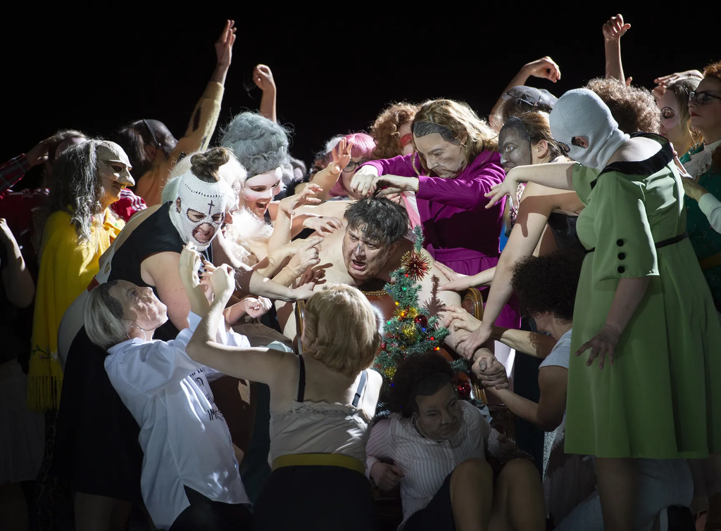

Monika Rittershaus

[Programm](https://www.die-hamburgische-staatsoper.de/de/programm/) → Oper

# Falstaff

Giuseppe Verdi

Inszenierung von 2020

- Sa 4.10. 19:30 Tickets
- Mi 8.10. 19:30 Tickets
- Zum letzten Mal in dieser Spielzeit

  Mi 15.10. 19:30 Tickets

Falstaff, so maß- wie skrupellos, schert sich nicht um Konventionen. Mit drastischen Mitteln inszenieren seine Opfer und deren Verbündete ein Verwirrspiel, das zu seiner Entlarvung und totalen Erniedrigung führt. Regisseur Calixto Bieito spürt in Verdis letzter großer Oper den Abgründen einer spätkapitalistischen Gesellschaft nach. In eindrücklichen Bildern zeigt er die komischen, aber auch die hässlichen Seiten menschlichen Miteinanders.

## „Regisseur Calixto Bieito blickt mit seiner Falstaff-Inszenierung in die Abgründe der modernen Gesellschaft.“ concerti

Commedia Lirica in drei Akten  
Komposition: Giuseppe Verdi  
Libretto: Arrigo Boito nach der Komödie The Merry Wives of Windsor and Passagen aus dem Drama King Henry IV von William Shakespeare

- 1893 9. Februar, Uraufführung am Teatro alla Scala in Mailand
- 2020 19. Januar, Premiere an der Hamburgischen Staatsoper
- 2025 Vortrag: 15. Oktober 2025, 18:45 findet im Vorderhaus der Hamburgischen Staatsoper das Gespräch „Die Welt da draußen: Anderssein als Chance“ zwischen Christopher Warmuth und Sasha Marianna Salzmann statt.

[interactive chart not shown]

## Besetzung

- Musikalische Leitung

  [Valerio Galli](https://www.die-hamburgische-staatsoper.de/de/personen/39915809-valerio-galli)
- Inszenierung

  [Calixto Bieito](https://www.die-hamburgische-staatsoper.de/de/personen/39912530-calixto-bieito)
- Bühnenbild

  [Susanne Gschwender](https://www.die-hamburgische-staatsoper.de/de/personen/39912417-susanne-gschwender)
- Kostüme

  [Anja Rabes](https://www.die-hamburgische-staatsoper.de/de/personen/39912757-anja-rabes)
- Licht

  [Michael Bauer](https://www.die-hamburgische-staatsoper.de/de/personen/3684-michael-bauer)
- Chor

  [Alice Meregaglia](https://www.die-hamburgische-staatsoper.de/de/personen/39915784-alice-meregaglia)
- Dramaturgie

  [Bettina Auer](https://www.die-hamburgische-staatsoper.de/de/personen/39913237-bettina-auer)
- Falstaff

  [Wolfgang Koch](https://www.die-hamburgische-staatsoper.de/de/personen/1731-wolfgang-koch)
- Ford

  [Andrii Kymach](https://www.die-hamburgische-staatsoper.de/de/personen/39916102-andrii-kymach)
- Fenton

  [Granit Musliu](https://www.die-hamburgische-staatsoper.de/de/personen/39916090-granit-musliu)
- Dr. Cajus

  [James Kryshak](https://www.die-hamburgische-staatsoper.de/de/personen/39914944-james-kryshak)
  - 4.10.25

  [Jürgen Sacher](https://www.die-hamburgische-staatsoper.de/de/personen/621-juergen-sacher)
  - 8.10.25 /
  - 15.10.25
- Bardolfo

  [Thomas Cilluffo](https://www.die-hamburgische-staatsoper.de/de/personen/2147496051-thomas-cilluffo)
  - 4.10.25

  [Daniel Kluge](https://www.die-hamburgische-staatsoper.de/de/personen/39913271-daniel-kluge)
  - 8.10.25 /
  - 15.10.25
- Pistola

  [Hubert Kowalczyk](https://www.die-hamburgische-staatsoper.de/de/personen/39913534-hubert-kowalczyk)
- Alice Ford

  [Elbenita Kajtazi](https://www.die-hamburgische-staatsoper.de/de/personen/39912957-elbenita-kajtazi)
- Nannetta

  [Narea Son](https://www.die-hamburgische-staatsoper.de/de/personen/39912231-narea-son)
- Mrs. Quickly

  [Kristina Stanek](https://www.die-hamburgische-staatsoper.de/de/personen/39914596-kristina-stanek)
- Meg Page

  [Katja Pieweck](https://www.die-hamburgische-staatsoper.de/de/personen/1991-katja-pieweck)
- [Chor der Hamburgischen Staatsoper](https://www.die-hamburgische-staatsoper.de/de/personen/5469-chor-der-hamburgischen-staatsoper)
- [Philharmonisches Staatsorchester Hamburg](https://www.die-hamburgische-staatsoper.de/de/personen/1929-philharmonisches-staatsorchester-hamburg)

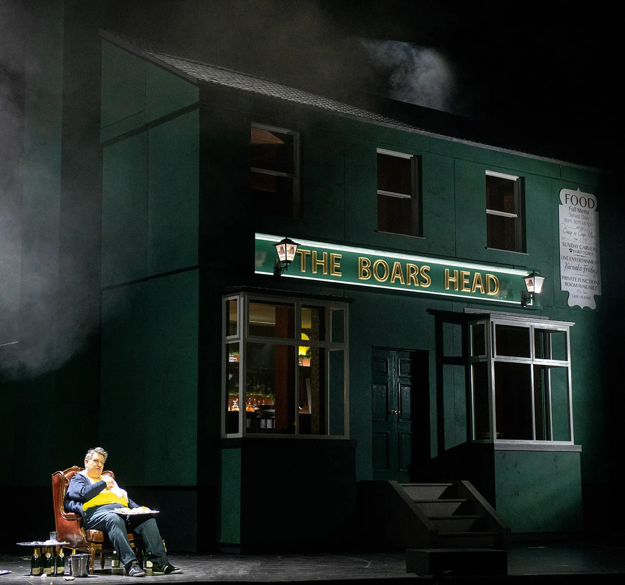

- **© ×**

  Monika Rittershaus

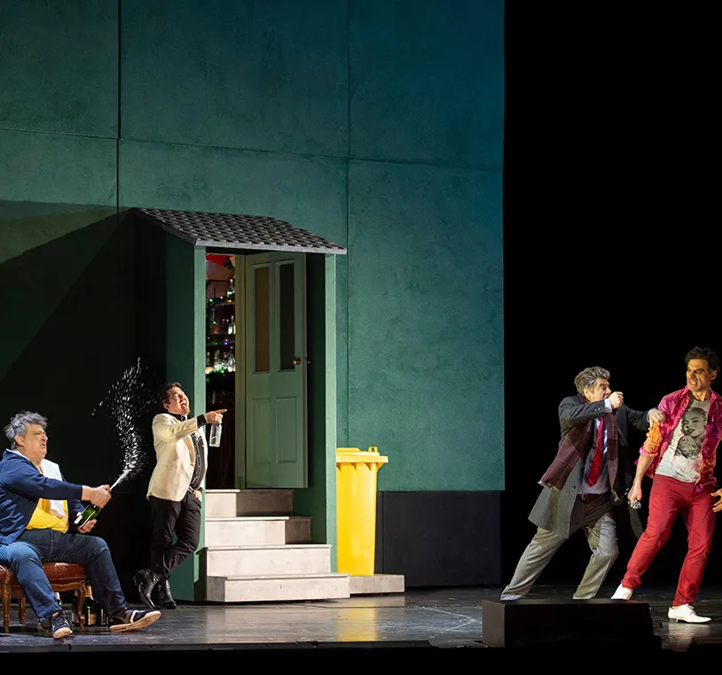

- **© ×**

  Monika Rittershaus

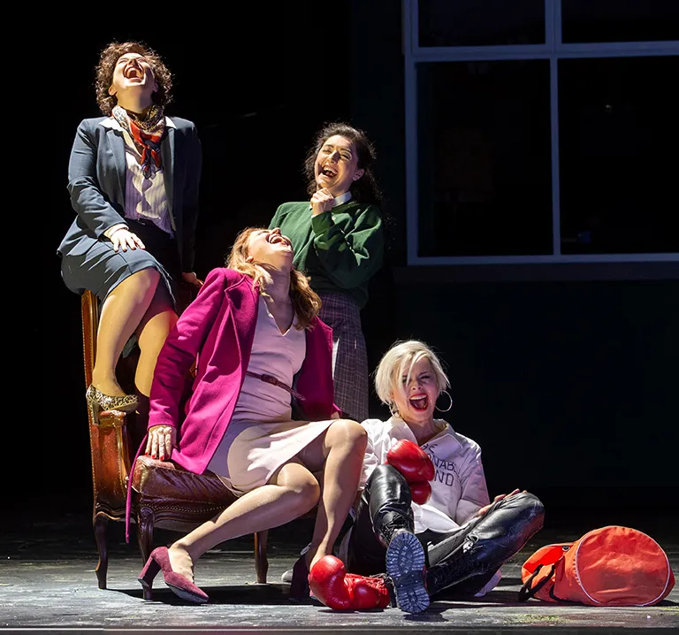

- **© ×**

  Monika Rittershaus

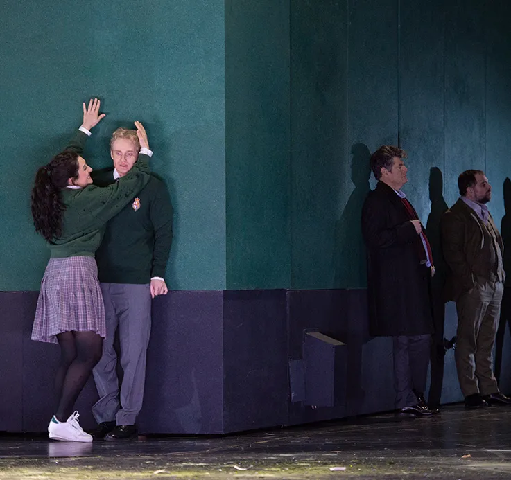

- **© ×**

  Monika Rittershaus

[figure not shown]

- **© ×**

  Monika Rittershaus

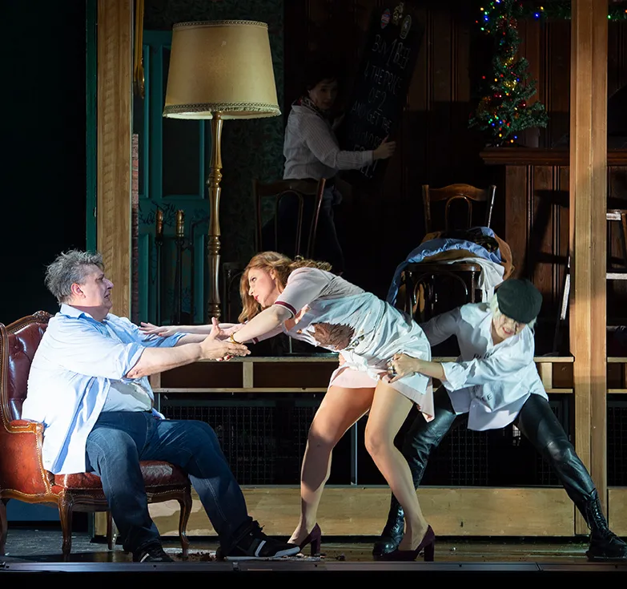

- **© ×**

  Monika Rittershaus

[figure not shown]

- **© ×**

  Monika Rittershaus

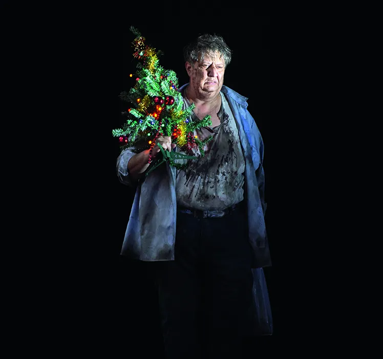

- **© ×**

  Monika Rittershaus

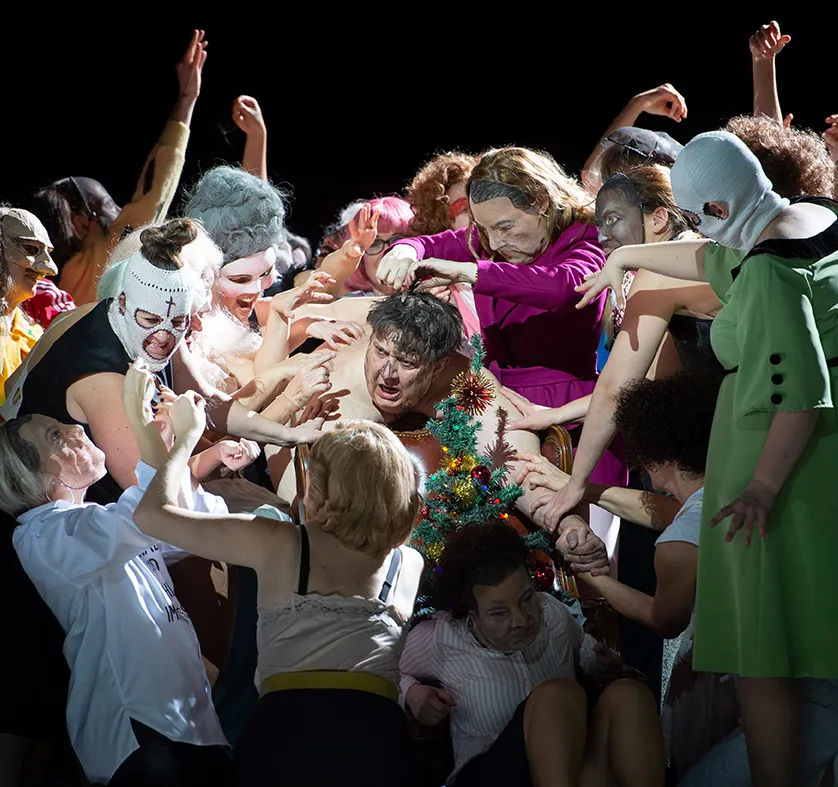

- **© ×**

  Monika Rittershaus

## Das Stück

- Spielstätte Staatsoper, Großes Haus
- Dauer 150 Min
- Pause Nach dem II. Akt
- Altersempfehlung Ab 14 Jahren / Klasse 9
- Sprache In italienischer Sprache mit deutschen und englischen Übertiteln

Die Titelfigur in Verdis letzter großer komischer Oper frönt vor allem dem Genuss. Skrupellos nimmt sich Falstaff, was er kriegen kann. Er schert sich nicht um Konventionen, frisst exzessiv, verführt zahllose Frauen. Doch bleibt dies nicht ohne Konsequenzen: Mit drastischen Mitteln inszenieren seine Opfer und deren Verbündete ein Verwirrspiel, das ihn entlarven soll und zur totalen Erniedrigung führt. In eindrücklichen Bildern spürt Regisseur Calixto Bieito den Abgründen einer spätkapitalistischen Gesellschaft nach, in der soziale Unterschiede nicht immer überbrückbar sind, Liebe schwer zu leben scheint. Er zeigt die hässliche und komische Seite großer und kleiner Gefühle, die möglichen Schattenseiten menschlichen Miteinanders, in dem Opfer- und Täterschaft nah beieinander liegen.  
Uraufgeführt wurde die Commedia lirica am 9. Februar 1893 an der Mailänder Scala. Die Hamburger Inszenierung feierte am 19. Januar 2020 Premiere.

Rahmenprogramm

Mit FRAMING the REPERTOIRE beleuchten wir vergangene Inszenierungen als eigenständige Kunstform.

[Mehr dazu](https://www.die-hamburgische-staatsoper.de/de/ueberuns/oper/framing-the-repertoire)

[figure not shown]

- - Musikalische Leitung [Valerio Galli](https://www.die-hamburgische-staatsoper.de/de/personen/39915809-valerio-galli)

  [Details](https://www.die-hamburgische-staatsoper.de/de/programm/oper/753-falstaff)
- - Musikalische Leitung [Valerio Galli](https://www.die-hamburgische-staatsoper.de/de/personen/39915809-valerio-galli)

  [Details](https://www.die-hamburgische-staatsoper.de/de/programm/oper/753-falstaff)
- - Musikalische Leitung [Valerio Galli](https://www.die-hamburgische-staatsoper.de/de/personen/39915809-valerio-galli)

  [Details](https://www.die-hamburgische-staatsoper.de/de/programm/oper/753-falstaff)

[interactive chart not shown]